# FI 362 — Day 1 Supplement

Asset Returns & Distributional Properties, Step by Step with Real Data

Author

Mehman Ismayilli

Published

June 22, 2026

> **How to use this notebook.** It mirrors the Day 1 slides (`FI362_Day01_FE`) section by section, but *computes* every concept on real market data instead of stating it abstractly. Read the slide, then run the matching block here. All data lives in the sibling `data/` folder and was built by `data/download_data.R` (daily Yahoo Finance prices, Jan 2000 – May 2026, adjusted for splits & dividends).

# 1 Setup & data

```r
library(ggplot2)
library(moments)   # skewness(), kurtosis() -- we also code the Tsay versions by hand
library(tseries)   # jarque.bera.test()
library(zoo)
library(knitr)

theme_set(theme_minimal(base_size = 12))

# Locate the data folder robustly (works whether rendered from this folder,
# the project root, or interactively).
data_dir <- local({
  cands <- c("../data", "data", file.path(getwd(), "data"))
  hit <- cands[file.exists(file.path(cands, "indices_adjclose.csv"))]
  if (!length(hit)) stop("Could not find the data/ folder. Run data/download_data.R first.")
  hit[1]
})

read_prices <- function(file) {
  df <- read.csv(file.path(data_dir, file), check.names = FALSE)
  df$Date <- as.Date(df$Date)
  df
}

indices   <- read_prices("indices_adjclose.csv")   # daily, wide
stocks    <- read_prices("stocks_adjclose.csv")     # daily, wide
idx_month <- read_prices("indices_monthly.csv")     # month-end, wide
sp_month  <- read_prices("sp500_monthly.csv")       # month-end S&P 500
meta      <- read.csv(file.path(data_dir, "metadata.csv"))

kable(meta[, c("symbol","name","region","asset_class","rows","start","end")],
      caption = "The downloaded universe of global indices and stocks.")
```

The downloaded universe of global indices and stocks.

| symbol | name | region | asset_class | rows | start | end |
| --- | --- | --- | --- | --- | --- | --- |
| ^GSPC | SP500 | United States | Equity index | 6641 | 2000-01-03 | 2026-05-29 |
| ^IXIC | NASDAQ | United States | Equity index | 6641 | 2000-01-03 | 2026-05-29 |
| ^DJI | DowJones | United States | Equity index | 6641 | 2000-01-03 | 2026-05-29 |
| ^FTSE | FTSE100 | United Kingdom | Equity index | 6719 | 2000-01-04 | 2026-05-29 |
| ^GDAXI | DAX | Germany | Equity index | 6747 | 2000-01-03 | 2026-05-29 |
| ^FCHI | CAC40 | France | Equity index | 6784 | 2000-01-03 | 2026-05-29 |
| ^N225 | Nikkei225 | Japan | Equity index | 6589 | 2000-01-04 | 2026-06-01 |
| ^HSI | HangSeng | Hong Kong | Equity index | 6583 | 2000-01-03 | 2026-05-29 |
| 000001.SS | SSEComposite | China | Equity index | 6519 | 2000-01-04 | 2026-05-29 |
| ^KS11 | KOSPI | South Korea | Equity index | 6603 | 2000-01-04 | 2026-06-01 |
| ^BSESN | Sensex | India | Equity index | 6596 | 2000-01-03 | 2026-05-29 |
| AAPL | AAPL | United States | Stock | 6641 | 2000-01-03 | 2026-05-29 |
| MSFT | MSFT | United States | Stock | 6641 | 2000-01-03 | 2026-05-29 |
| AXP | AXP | United States | Stock | 6641 | 2000-01-03 | 2026-05-29 |
| CAT | CAT | United States | Stock | 6641 | 2000-01-03 | 2026-05-29 |
| SBUX | SBUX | United States | Stock | 6641 | 2000-01-03 | 2026-05-29 |

We will use the **S&P 500** as our running example index and **AAPL** as our running example stock, but every computation generalises to any column.

```r
# --- log / simple return helpers -------------------------------------------
lag1       <- function(x) c(NA, head(x, -1))       # tiny one-step lag, no deps
simple_ret <- function(p) p / lag1(p) - 1          # R_t = P_t/P_{t-1} - 1
log_ret    <- function(p) c(NA, diff(log(p)))      # r_t = ln P_t - ln P_{t-1}

# --- sample moments EXACTLY as defined on the slides (Tsay, T-1 scaling) ----
samp_stats <- function(x) {
  x  <- x[is.finite(x)]
  T  <- length(x)
  m  <- mean(x)
  s  <- sqrt(sum((x - m)^2) / (T - 1))             # sample sd
  sk <- sum((x - m)^3) / ((T - 1) * s^3)           # sample skewness
  ku <- sum((x - m)^4) / ((T - 1) * s^4)           # sample kurtosis
  data.frame(n = T, mean = m, sd = s, skew = sk,
             exkurt = ku - 3, min = min(x), max = max(x))
}

# --- normality test statistics (slides: skew, kurtosis, Jarque-Bera) --------
norm_tests <- function(x) {
  x  <- x[is.finite(x)]; T <- length(x)
  st <- samp_stats(x)
  t_sk <- st$skew   / sqrt(6  / T)                 # H0: S = 0
  t_ku <- st$exkurt / sqrt(24 / T)                 # H0: K - 3 = 0
  JB   <- t_sk^2 + t_ku^2                           # = S^2/(6/T) + (K-3)^2/(24/T)
  data.frame(skew = st$skew, t_skew = t_sk, p_skew = 2 * (1 - pnorm(abs(t_sk))),
             exkurt = st$exkurt, t_kurt = t_ku, p_kurt = 2 * (1 - pnorm(abs(t_ku))),
             JB = JB, p_JB = 1 - pchisq(JB, df = 2))
}
```

# 2 From prices to returns

> *Slides: “Asset Returns – One period”.* A one-period **simple gross return** is $1+R_t = P_t/P_{t-1}$; the **simple net return** is $R_t = P_t/P_{t-1}-1$.

```r
sp <- data.frame(Date = indices$Date, Price = indices$SP500)
sp <- sp[is.finite(sp$Price), ]
sp$R  <- simple_ret(sp$Price)        # simple net return
sp$r  <- log_ret(sp$Price)           # log return (next section)

kable(head(sp, 6), digits = 5,
      caption = "S&P 500: price, simple net return R_t, and log return r_t.")
```

S&P 500: price, simple net return R_t, and log return r_t.

| Date | Price | R | r |
| --- | --- | --- | --- |
| 2000-01-03 | 1455.22 | NA | NA |
| 2000-01-04 | 1399.42 | -0.03834 | -0.03910 |
| 2000-01-05 | 1402.11 | 0.00192 | 0.00192 |
| 2000-01-06 | 1403.45 | 0.00096 | 0.00096 |
| 2000-01-07 | 1441.47 | 0.02709 | 0.02673 |
| 2000-01-10 | 1457.60 | 0.01119 | 0.01113 |

Why we prefer returns to prices: returns are **scale-free** (a complete summary of the investment, independent of how many shares you hold) and far better behaved statistically. Compare the price *level* with the return *series*:

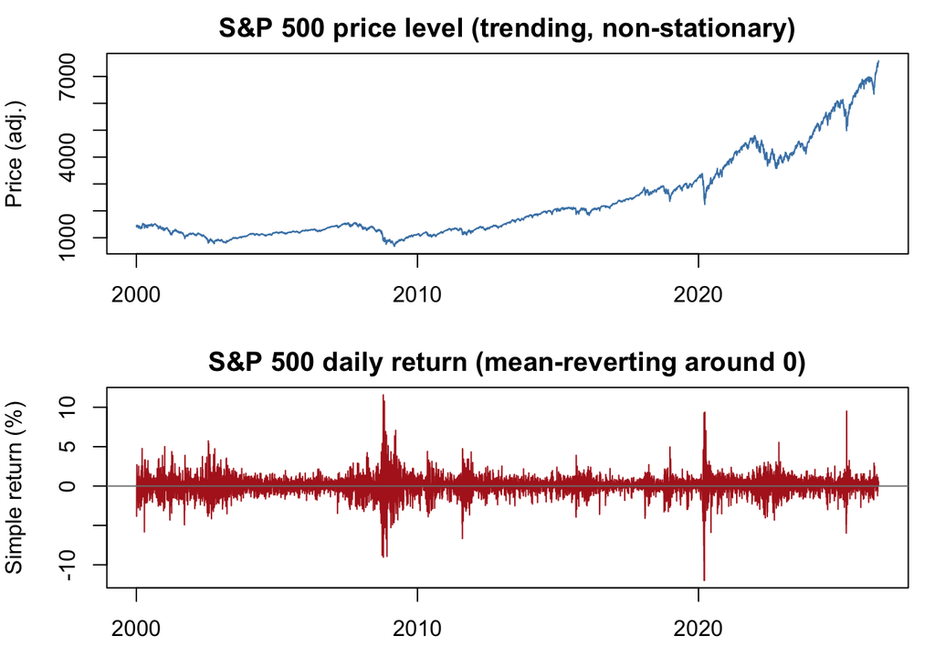

```r
op <- par(mfrow = c(2, 1), mar = c(3, 4, 2, 1))
plot(sp$Date, sp$Price, type = "l", col = "steelblue",
     xlab = "", ylab = "Price (adj.)", main = "S&P 500 price level (trending, non-stationary)")
plot(sp$Date, 100 * sp$R, type = "l", col = "firebrick",
     xlab = "", ylab = "Simple return (%)", main = "S&P 500 daily return (mean-reverting around 0)")
abline(h = 0, col = "grey50"); par(op)
```

# 3 Multi-period returns & compounding

> *Slides: “Asset Returns – Multi-period”.* The $k$-period gross return is the **product** of one-period gross returns, $1+R_t[k] = \prod_{j=0}^{k-1}(1+R_{t-j})$.

Let us verify this identity on a concrete window — the 5 trading days after 2000-01-03 — by compounding daily returns and comparing to the direct price ratio $P_t/P_{t-k}$.

```r
w <- sp[2:6, ]                                  # five consecutive days
gross_prod <- prod(1 + w$R)                     # product of (1+R)
direct     <- sp$Price[6] / sp$Price[1]         # P_t / P_{t-k}
c(`compounded product` = gross_prod, `direct price ratio` = direct,
  difference = gross_prod - direct)
```

```
compounded product direct price ratio         difference
      1.001635e+00       1.001635e+00      -2.220446e-16
```

They agree to numerical precision — compounding *is* the price ratio.

```r
R <- na.omit(sp$R)
geo  <- prod(1 + R)^(252 / length(R)) - 1       # exact geometric annualisation
arith <- mean(R) * 252                           # arithmetic approximation
log_based <- exp(mean(log(1 + R)) * 252) - 1     # via log returns
c(`geometric (exact)` = geo, `arithmetic approx` = arith,
  `log-mean based` = log_based)
```

```
geometric (exact) arithmetic approx    log-mean based
       0.06463743        0.08127200        0.06463743
```